# Bent Winter 2000

R. G. Cronce

12/17/2019

```r
library(reticulate)
```

# Bent, Winter 2000

Brain Ticklers from the Bent of Tau Beta Pi.

## Problem 1

VCR counter proportional to number of rotations of the take-up reel. When the counter reads 1000 it is increasing at a rate of 1 count per second. At 2000 seconds, the counter is increasing at a rate of 2/3 count per second. Express time, t, as a function of the number of counts, c.

– Greg A. Qualls, KS B’80

## Problem 2

George’s new office has a combination lock. Each digit is unique. He wrote down a subset of the numbers on a piece of paper along with the security combination. Multiplying the two numbers together yields 7 digit number, all of the same digit. What is the combination?

– Adapted from *New Scientist*

The 7 digit number must be n*1111111 where n = 1, 2, …, 9. Let us factor 1111111 to see what we have to deal with:

```python
import sympy

sympy.factorint(1111111)
```

```
## {239: 1, 4649: 1}
```

So, the factors are 239*4649. The second number can not be the combination since it does not contain unique digits. The first can’t be the combination since the second is not a subset of the digits. We conclude that the product is not 1111111. Let’s look at the other possibilites:

```python
for i in range(1,10):
  print(i*1111111,sympy.factorint(i*1111111))
```

```
## 1111111 {239: 1, 4649: 1}
## 2222222 {2: 1, 239: 1, 4649: 1}
## 3333333 {3: 1, 239: 1, 4649: 1}
## 4444444 {2: 2, 239: 1, 4649: 1}
## 5555555 {5: 1, 239: 1, 4649: 1}
## 6666666 {2: 1, 3: 1, 239: 1, 4649: 1}
## 7777777 {7: 1, 239: 1, 4649: 1}
## 8888888 {2: 3, 239: 1, 4649: 1}
## 9999999 {3: 2, 239: 1, 4649: 1}
```

We can look at all the factors of each of the numbers to check for the following conditions:

1. Combination must have unique digits, subset must have unique digits
2. Subset must be a subset of the combination
3. Product of the combination subset must be `n*1111111`

Combinations:

```
1111111: 239, 4649               - not feasible (repeated digits)
2222222: 2*239=478, 4649         - not feasible (repeated digits)
         239, 2*4649=9298        - not feasible (repeated digits)
3333333: 3*239=717, 4649         - not feasible (repeated digits)
         239, 3*4649=13947       - not feasible (239 not a subset of 13947)
4444444: 239, 4*4249=16996       - not feasible (repeated digits)
         239*2=478, 2*4249=9298  - not feasible (repeated digits)
         239*4=956, 4249         - not feasible (repeated digits)
5555555: 239, 5*4649=23245       - not feasible (repeated digits)
         5*239=1195, 4649        - not feasible (repeated digits)
6666666: 239, 6*4649=27894       - not feasible (239 not a subset of 27894)
         239*2=478, 3*4649=13947 - not feasible (478 not a subset of 13947)
         239*3=717, 2*4649=9298  - not feasible (repeated digits)
         239*6=1434, 4649        - not feasible (repeated digits)
7777777: 7*239=1673,4649         - not feasible (repeated digits)
         239, 7*4649=32543       - not feasible (repeated digits)
8888888: 239, 8*4649=37192       - feasible
         2*239=478,4*4649=18596  - not feasible (478 not a subset of 18596)
         4*239=956,2*4649=9298   - not feasible (repeated digits)
         8*239=1912,4649         - not feasible (repeated digits)
9999999  239, 9*4649=41841       - not feasible (repeated digits)
         3*239=717,3*4649=13947  - not feasible (repeated digits)
         9*239=2151,4649         - not feasible (repeated digits)
```

Only a multiplier of 8 works - so we conclude:

```
Security code = 8*4649 = 37192
Subset of digits = 239

Product = 37192*239 = 8888888
```

## Problem 3

Some friends are golfing and like to celebrate at the end of the round. There are 32 people. They want to celebrate a birthday but one month there are no birthdays.

For a group of 32 people, what are the odds that there is at least one month during the year that has no birthdays? Assume all months are equiprobable.

– John W. Langhaar, PA A’33

```r
# Let's use Monte-Carlo

n_trials=1000000
n=0
for (i in 1:n_trials) {
  n=n+(length(unique(sample(12,32,replace=T)))<12)
}
n/n_trials
```

```
## [1] 0.569707
```

A somewhat surprising result – more than half the time there is one or more months without any birthdays in a group of 32 people.

## Problem 4

Ladder of length L - one end in contact with floor and the other with the wall. As ladder slides from vertical to horizontal, what is the equation of the area swept out by the ladder?

– *Technology Review*

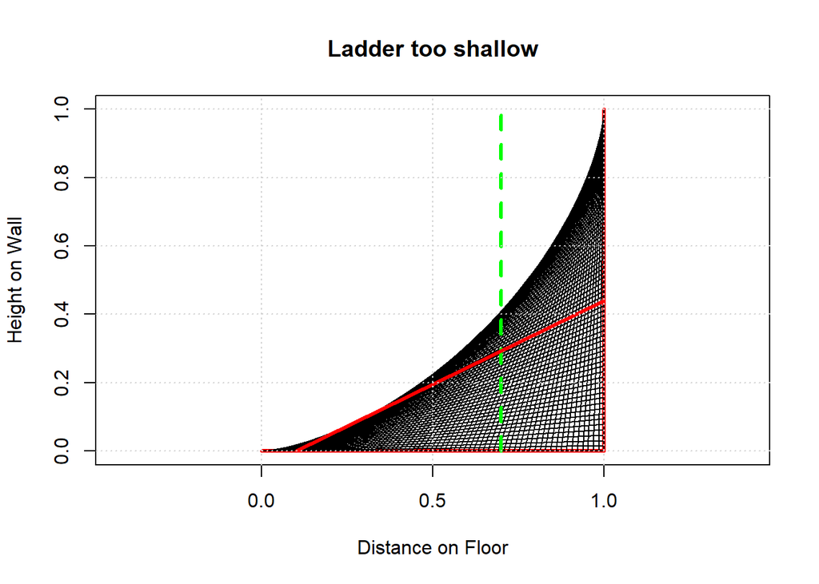

```r
# Let's make a plot to visualize the situation
# Let the ladder length be normalized to 1.0
# Let the angle of the ladder vary from 0 to pi/2 wrt the floor

num_lines=101
theta=seq(0,pi/2,length=num_lines)
x=(1-cos(theta))
y=sin(theta)

# Plot the first line and set the limits
plot(c(0,1),c(0,0),col='red',lwd=3,
     xlim=c(0,1),
     ylim=c(0,1),
     xlab="Distance on Floor",
     ylab="Height on Wall",
     asp=1,
     type='l')
title('Ladder too shallow')
lines(c(1,1),c(0,1),col='red',lwd=3)
for (i in seq_along(theta)) {
  lines(c(x[i],1),c(0,y[i]))
}
# Target X-value
lines(c(0.7,0.7),c(0,1),col='green',lwd=3,lty=2)
# Example position(s) of the ladder
lines(c(x[trunc(0.3*num_lines)],1),c(0,y[trunc(0.3*num_lines)]),col='red',lwd=3)
# lines(c(x[trunc(0.5*num_lines)],1),c(0,y[trunc(0.5*num_lines)]),col='green',lwd=3)
# lines(c(x[trunc(0.7*num_lines)],1),c(0,y[trunc(0.7*num_lines)]),col='green',lwd=3)
grid()
```

The situation is shown above. The green dashed line shows the target value of X. We want to find the angle of the ladder that maximizes Y for this value of X. Clearly, the position of the ladder shown above is too shallow. Need to increase the angle (and, therefore, move the ladder). By trial and error we can get the answer as shown below.

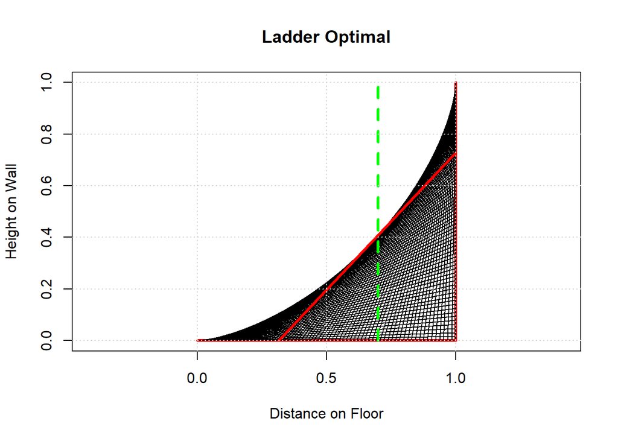

```r
# Let's make a plot to visualize the situation
# Let the ladder length be normalized to 1.0
# Let the angle of the ladder vary from 0 to pi/2 wrt the floor

num_lines=101
theta=seq(0,pi/2,length=num_lines)
x=(1-cos(theta))
y=sin(theta)

# Plot the first line and set the limits
plot(c(0,1),c(0,0),col='red',lwd=3,
     xlim=c(0,1),
     ylim=c(0,1),
     xlab="Distance on Floor",
     ylab="Height on Wall",
     asp=1,
     type='l')
title('Ladder Optimal')
lines(c(1,1),c(0,1),col='red',lwd=3)
for (i in seq_along(theta)) {
  lines(c(x[i],1),c(0,y[i]))
}
# Target X-value
lines(c(0.7,0.7),c(0,1),col='green',lwd=3,lty=2)
# Example position(s) of the ladder
lines(c(x[trunc(0.53*num_lines)],1),c(0,y[trunc(0.53*num_lines)]),col='red',lwd=3)
# lines(c(x[trunc(0.5*num_lines)],1),c(0,y[trunc(0.5*num_lines)]),col='green',lwd=3)
# lines(c(x[trunc(0.7*num_lines)],1),c(0,y[trunc(0.7*num_lines)]),col='green',lwd=3)
grid()
```

This shows the ladder in the optimal position with an angle of (approx.) 0.82 Radians. Note that if you increase the angle even further, the height at the target X value decreases:

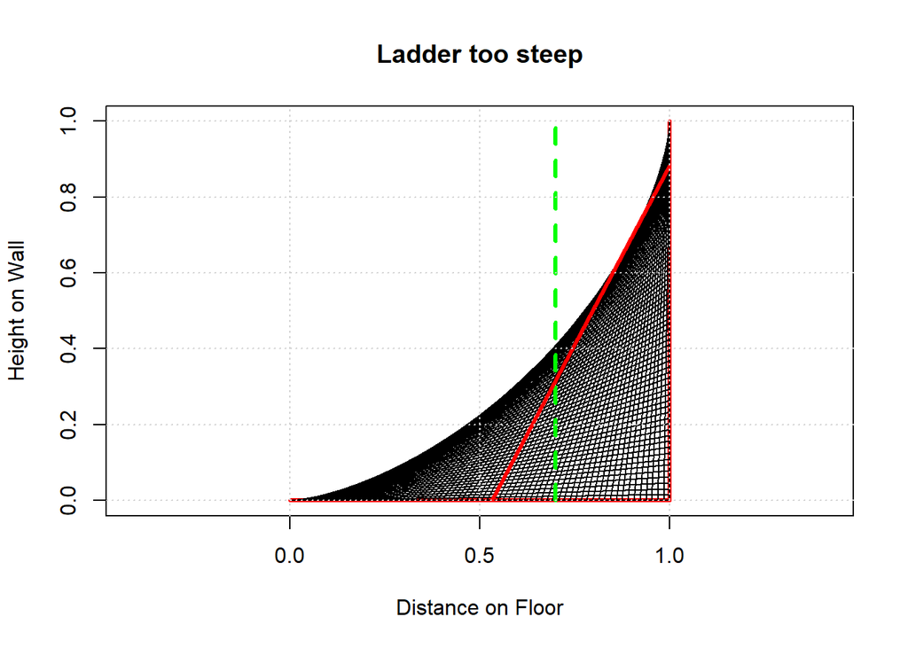

```r
# Let's make a plot to visualize the situation
# Let the ladder length be normalized to 1.0
# Let the angle of the ladder vary from 0 to pi/2 wrt the floor

num_lines=101
theta=seq(0,pi/2,length=num_lines)
x=(1-cos(theta))
y=sin(theta)

# Plot the first line and set the limits
plot(c(0,1),c(0,0),col='red',lwd=3,
     xlim=c(0,1),
     ylim=c(0,1),
     xlab="Distance on Floor",
     ylab="Height on Wall",
     asp=1,
     type='l')
title('Ladder too steep')
lines(c(1,1),c(0,1),col='red',lwd=3)
for (i in seq_along(theta)) {
  lines(c(x[i],1),c(0,y[i]))
}
# Target X-value
lines(c(0.7,0.7),c(0,1),col='green',lwd=3,lty=2)
# Example position(s) of the ladder
lines(c(x[trunc(0.7*num_lines)],1),c(0,y[trunc(0.7*num_lines)]),col='red',lwd=3)
# lines(c(x[trunc(0.5*num_lines)],1),c(0,y[trunc(0.5*num_lines)]),col='green',lwd=3)
# lines(c(x[trunc(0.7*num_lines)],1),c(0,y[trunc(0.7*num_lines)]),col='green',lwd=3)
grid()
```

We can parameterize the height at a particular target X value in terms of the ladder angle (or position) and then maximize the height:

```python
from sympy import *
y=symbols('y')     # Height of ladder at the target X value
x=symbols('x')     # Target X value
theta=symbols('theta')   # Angle of the ladder

# Distance between target X and the ladder at the floor
base=x-(1-cos(theta))
height=y
y=(x-(1-cos(theta)))*tan(theta)
# Convert the result to degrees
print(N(solve(simplify(diff(y,theta)),theta)[0]*180/pi))
```

```
## -60.0 - 1.77727342478755e-22*I
```

```python
print(N(solve(simplify(diff(y,theta)),theta)[1]*180/pi))
```

```
## 60.0 - 1.77727342478755e-22*I
```

This says the solution is +/- 60 degrees — which is clearly wrong — so needs more work.

## Problem 5

A candle in the shape of a truncated right circular cone is 45 cm high. It burns to extinction in 9 hours. The bottom 3 cm takes 20 minutes longer to burn than the top 3 cm. How many minutes does it take for the top 3 cm to burn? Assume the candle volume decreases at a constant rate.

– Marcello J. Carrabes, MA E’50

```python
import sympy
from sympy import *

r1=symbols('r1')    # Radius at bottom of candle
r2=symbols('r2')    # Radius at top of candle (smaller than r1)
y=symbols('y')      # Height above base
r=r1-(r1-r2)*y/45   # Radius of candle as a function of height
H=45                # Height of candle
V=integrate(pi*r**2,(y,0,H))   # Total volume of candle
T=9*60              # Burning time of total candle in minutes
K=V/T               # Burn rate

t_low = integrate(pi*r**2,(y,0,3))/K      # Time to burn bottom 3 cm
t_high = integrate(pi*r**2,(y,42,45))/K   # Time to burn top 3 cm
R1 = solve(t_low-t_high-20,r1)[0]         # Bottom takes 20 mins longer to burn

print("Symbolically:")
```

```
## Symbolically:
```

```python
print('Burn time for top 3 cm    = ',simplify(t_high.subs(r1,R1)))
```

```
## Burn time for top 3 cm    =  -26*sqrt(61629)/225 + 1378/25
```

```python
print('Burn time for bottom 3 cm = ',simplify(t_low.subs(r1,R1)))
```

```
## Burn time for bottom 3 cm =  -26*sqrt(61629)/225 + 1878/25
```

```python
print("Numerically:")
```

```
## Numerically:
```

```python
print('Burn time for top 3 cm    = ',N(simplify(t_high.subs(r1,R1))))
```

```
## Burn time for top 3 cm    =  26.4331151401383
```

```python
print('Burn time for bottom 3 cm = ',N(simplify(t_low.subs(r1,R1))))
```

```
## Burn time for bottom 3 cm =  46.4331151401383
```

## Bonus

There are two integers, A and B, which are greater than 1 and less than 101. Neither Sam nor Pete knows what they are but Sam knows the sum and Pete knows the product. The following conversation takes place:

```
Pete: "I don't know what the numbers are."
Sam:  "I knew that you didn't"
Pete: "Now I know what they are"
Sam:  "Then so do I"
```

What are the numbers A and B?

– *Don Holden*

## Double Bonus

A good approximation of pi using the digits 1 through 9 each once is:

```
pi ~ 3 + (16 - 8**(-5))/(97+2**4)
```

Find a better approximation using each digit once with the operations limited to addition, subtraction, multiplication, division, exponentiation, decimal points, and parentheses.

– Richard I. Hess, CA B’62